# SDS/CSC 293 Mini-Project 4: CART

Group 04: Willow Crawford-Crudell & Bushra Tasneem

Wednesday, April 17<sup>th</sup>, 2019

You will be fitting CART models to the data from the [Ghouls, Goblins, and Ghosts… Boo!](https://www.kaggle.com/c/ghouls-goblins-and-ghosts-boo/) Kaggle competition. The competition’s score for leaderboard purposes is the “Categorization Accuracy”. However you will **NOT** be making any submissions to Kaggle.

# Load data

Read in data provided by Kaggle for this competition. They are organized in the `data/` folder of this RStudio project:

```r
training <- read_csv("data/train.csv")
test <- read_csv("data/test.csv")
sample_submission <- read_csv("data/sample_submission.csv")
```

## Look at your data!

Always, ALWAYS, **ALWAYS** start by looking at your raw data. This gives you visual sense of what information you have to help build your predictive models. To get a full description of each variable, read the data dictionary in the `data_description.txt` file in the `data/` folder.

Note that the following code chunk has `eval = FALSE` meaning “don’t evaluate this chunk with knitting” because `.Rmd` files won’t knit if they include a `View()`:

```r
View(training)
glimpse(training)

View(test)
glimpse(test)
```

In particular, pay close attention to the variables and variable types in the `sample_submission.csv`. Your submission must match this exactly.

```r
glimpse(sample_submission)
```

```
## Observations: 529
## Variables: 2
## $ id   <dbl> 3, 6, 9, 10, 13, 14, 15, 16, 17, 18, 20, 21, 24, 26, 33, 38…
## $ type <chr> "Ghost", "Ghost", "Ghost", "Ghost", "Ghost", "Ghost", "Ghos…
```

# Minimally viable product

Perform the following exploratory data analyses:

## Univariate explorations

**Categorical predictor**: Create a visualization of the categorical predictor variable `color`.

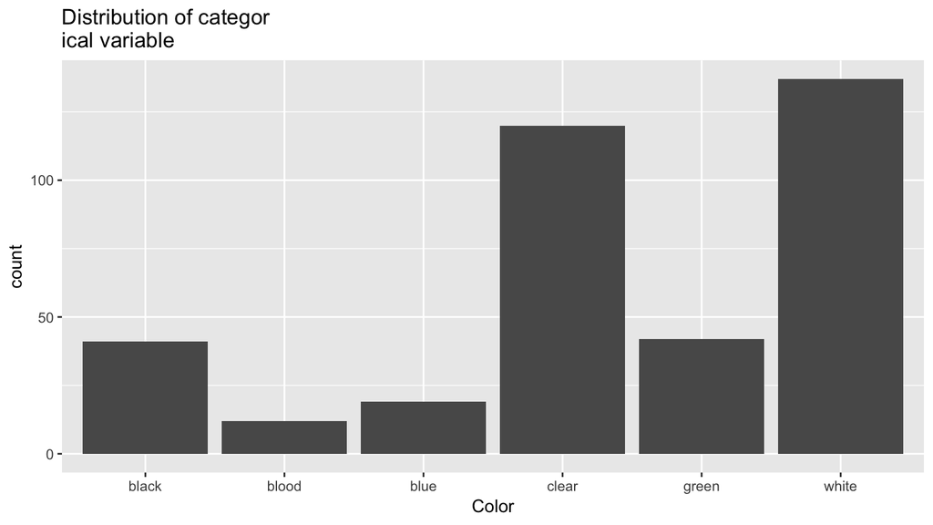

```r
ggplot(training, aes(x = color)) +
  geom_bar() +
  labs(x = "Color", title = "Distribution of categor
ical variable")
```

**Outcome variable**: Create a visualization of the categorical predictor variable `type`.

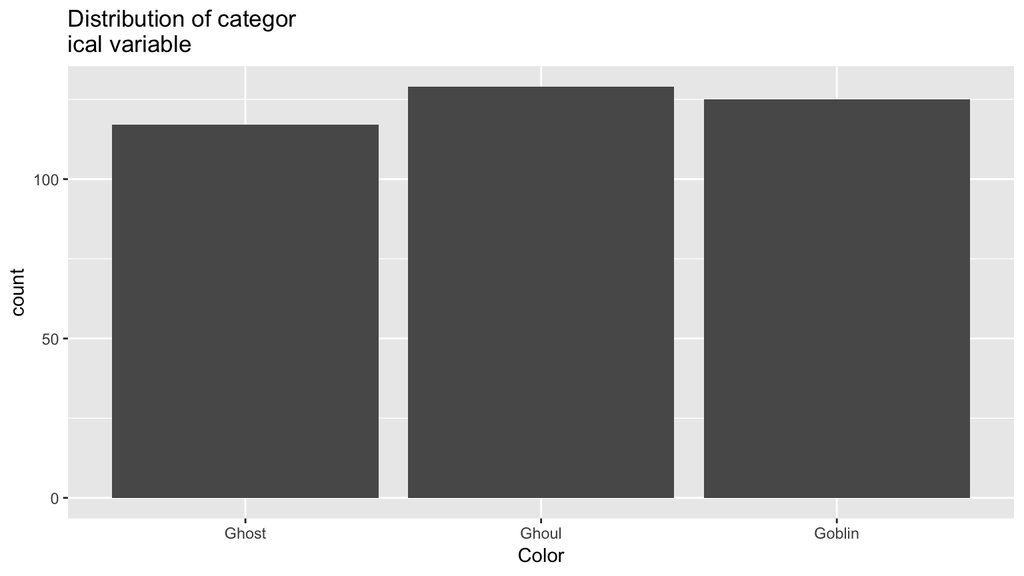

```r
ggplot(training, aes(x = type)) +
  geom_bar() +
  labs(x = "Color", title = "Distribution of categor
ical variable")
```

## Mutlivariate explorations

**Numerical predictors**: Create a visualization of the relationship of all four numerical predictor variables at once (`bone_length`, `rotting_flesh`, `hair_length`, `has_soul`) using the `ggpairs()` function from the `GGally` [package](http://ggobi.github.io/ggally/#ggallyggpairs).

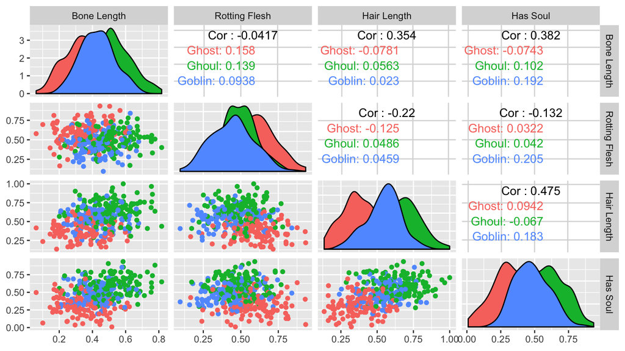

```r
pm <- ggpairs(training, mapping = aes(color= type), columns = c("bone_length", "rotting_flesh", "hair_length", "has_soul"), columnLabels = c("Bone Length", "Rotting Flesh", "Hair Length", "Has Soul"))
pm
```

# Due diligence

1. Fit a CART where:
   - You use only the numerical predictors.
   - The maximum depth of the tree is 5.
   - You use the default “complexity parameter”
2. Plot the tree.
3. Make predictions `type_hat` on the `training` data. Hint compare the output of `predict(model_CART, type = "prob")` and `predict(model_CART, type = "class")`.
4. Compute the “classification accuracy”.

[figure not shown]

```r
model_formula <- as.formula(type ~ has_soul+hair_length+bone_length+rotting_flesh)
tree_parameters <- rpart.control(maxdepth = 5)
model_CART <- rpart(model_formula, data = training, control = tree_parameters)

# Plot CART model
plot(model_CART, margin=0.5)
text(model_CART, use.n = TRUE)
title("Predicting iris species using sepal length & width")
box()
```

```r
p_hat_matrix_train_class <- model_CART %>%
  predict(type = "class", newdata = training) %>%
  # Convert matrix object to data frame:
  as_tibble()
```

```r
# Create a new data frame:
bind_cols(
  # Observed y:
  true = training$type,
  # Fitted probabilities for each class
  estimated = p_hat_matrix_train_class$value
) %>%
  # Compute multi-class log-loss
  accuracy(truth= factor(true), estimate = estimated)
```

| .metric | .estimator | .estimate |
| --- | --- | --- |
| accuracy | multiclass | 0.8032345 |

# Reaching for the stars

Note that the $\alpha$ complexity parameter is the `cp` argument to `rpart.control()`.

```r
alpha_df <- tibble(
  alpha = seq(from = 0, to = 0.1, length = 150),
  accuracy = 0
)
set.seed(76)
```

```r
set.seed(76)
training <- training %>%
  sample_frac(1) %>%
  mutate(fold = rep(1:5, length = n())) %>%
  arrange(fold)



for(i in 1:nrow(alpha_df)){
  alpha <- alpha_df$alpha[i]

  accu <- rep(0, 5)
  for(j in 1:5){
    pretend_training <- training %>%
      filter(fold != j)
    pretend_test <- training %>%
      filter(fold == j)

    # Fit model on pretend training
model_formula <- as.formula(type ~ has_soul+hair_length+bone_length+rotting_flesh)
tree_parameters <- rpart.control(maxdepth = 5, cp = alpha)
model_CART <- rpart(model_formula, data = pretend_training, control = tree_parameters)

    # Make predictions
 p_hat_matrix_test <- model_CART %>%
  predict(type = "class", newdata = pretend_test) %>%
  # Convert matrix object to data frame:
  as_tibble()

# Create a new data frame:
value <- bind_cols(
  # Observed y:
  true = pretend_test$type,
  # Fitted probabilities for each class
  estimated = p_hat_matrix_test$value
) %>%
  # Compute multi-class log-loss
  accuracy(truth= factor(true), estimate = estimated)
  }

  accu[j] <- value$.estimate
  alpha_df$accuracy[i] <- mean(accu)
}
```

# Point of diminishing returns

[figure not shown]